# Mel M

2018-03-18

Mel Moreno began her six-week internship in Mathieu Basille’s lab in May 2017. As a Miami native, she was familiar with Davie, and thrilled to return to South Florida for the summer. Mel Moreno was an ideal candidate for this internship, because of her interest with R, and spatial ecology. Mel had taken Quantitative Ecology (WIS 4601) in Fall 2016, and realized she had a real knack for R data analysis.

[figure not shown]

Graduation Fall 2017

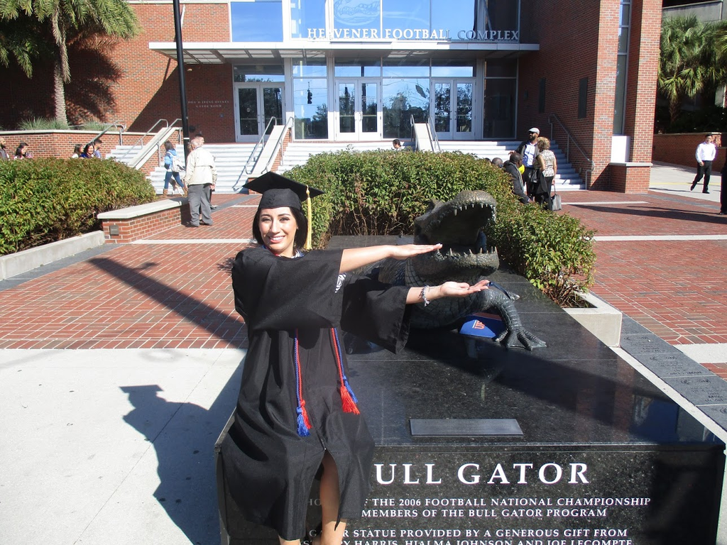

Graduation Fall 2017

Mel Moreno has recently graduated student from the University of Florida in Gainesville, FL. She graduated in Fall 2017 with a B.S in Wildlife Ecology and Conservation.

Mel, during her undergraduate career has competed in the The Florida Chapter of the Wildlife Society, conclave competition in March 2017.

[figure not shown]

Mel also was awarded the MINRC, Minorities in Natural Resource Conservation, stipend to attend the SEAFWAS Conference in Fall 2016. There she was award the Theodore Roosevelt Conservation Award, for best essay on how growing up as a minority has given her a different perspective on conservation

[figure not shown]

Mel is currently working under Dr. Bill Pine on an Oyster Restoration Project (http://www.wec.ufl.edu/oysterproject/restoration.php). She is assisting on creating visualizations for data collected from Cedar Key, FL. She is currently in the process of creating a Shiny APP, with the help of other students in the University of Florida, specifically for this project.

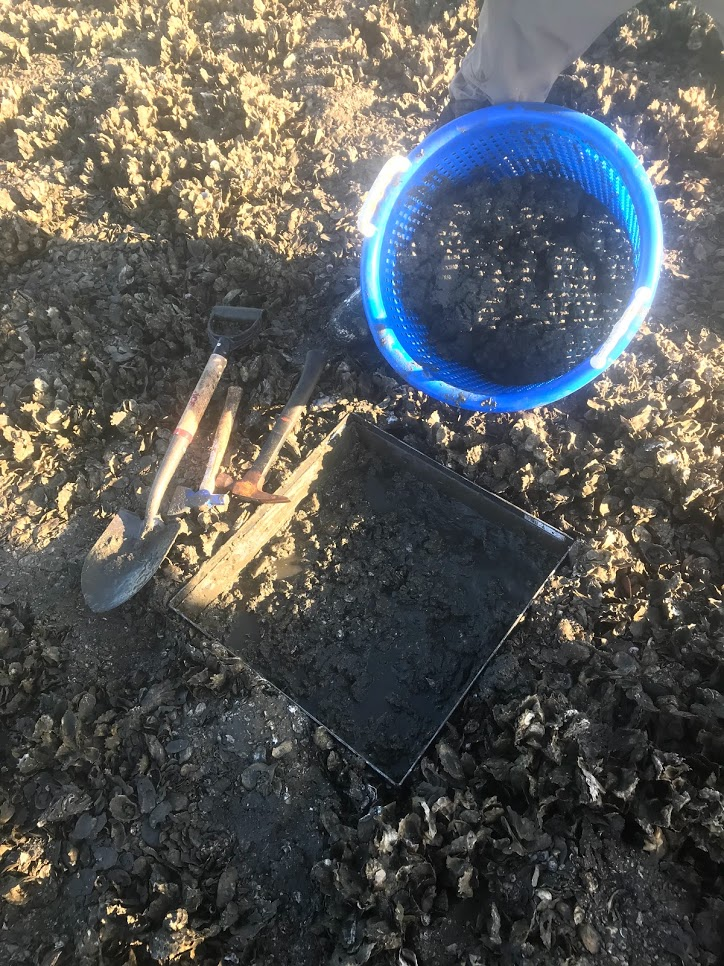

Oyster Quadrat in Cedar Key, FL